# Introduction to `ggplot`

### `aes`

`aes` will be one of the functions that you will most use. The function connects data with what we see on the graph. We refer to this connection as the **aesthetic mappings**. The outcome of this function is often used as the argument of a geometry function. This example produces a scatter plot of total murders versus population in millions:

```r
murders %>% ggplot() +
            geom_point(aes(x = population/10^6, y = total))
```

Note that we can drop the `x =` and `y =` if we wanted to as these are the first and second expected arguments as seen on the help page.

Also note that we can add a layer to the `p` object that was defined above as `p <- ggplot(data = murders)`:

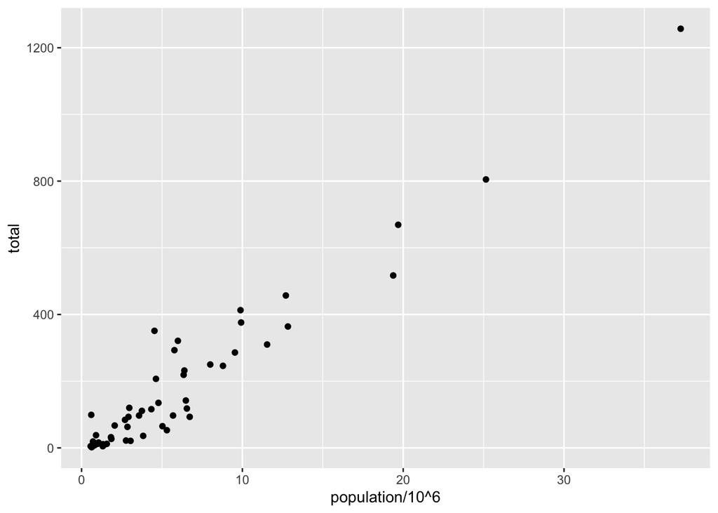

```r
p <- murders %>% ggplot()

p + geom_point(aes(population/10^6, total))
```

Note that the scale and labels are defined by default when adding this layer. Also notice that we use the variable names from the object component: `population` and `total`.

Keep in mind that the behavior of recognizing the variables from the data component is quite specific to `aes`. With most functions, if you try to access the values of `population` or `total` outside of `aes` you receive an error.

#### Adding other layers

Because each state (each point) has a label we need an aesthetic mapping to make the connection. By reading the help file we learn that we supply the mapping between point and label through the `label` argument of `aes`. So the code looks like this:

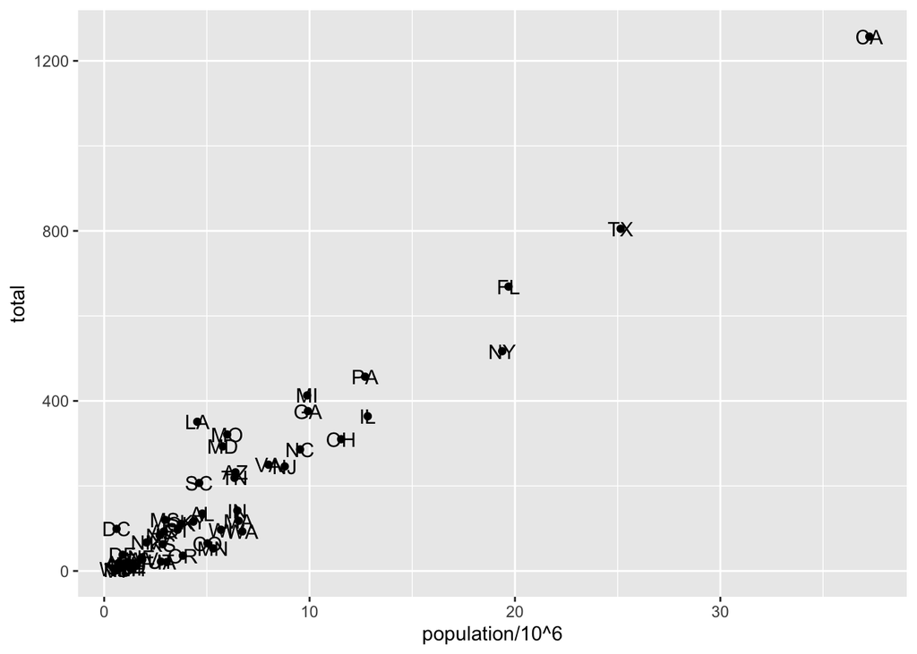

```r
p + geom_point(aes(population/10^6, total)) +
    geom_text(aes(population/10^6, total, label = abb))
```

We have successfully added a second layer to the plot.

As an example of the unique behavior of `aes` mentioned above, note that this call

```r
p_test <- p + geom_text(aes(population/10^6, total, label = abb))
```

is fine, this call

```r
p_test <- p + geom_text(aes(population/10^6, total), label = abb)
```

will give you an error as `abb` is not found once it is outside of the `aes` function and `geom_text` does not know where to find `abb` as it is not a global variable.

#### Tinkering with other arguments

Note that each geometry function has many arguments other than `aes` and `data`. They tend to be specific to the function. For example, in the plot we wish to make, the points are larger than the default ones. In the help file we see that `size` is an aesthetic and we can change it like this:

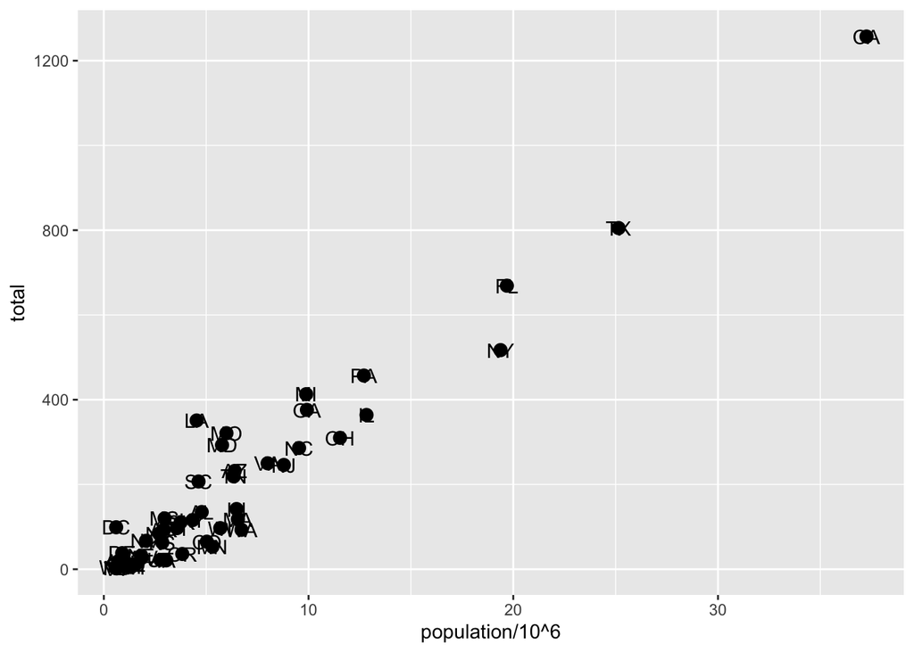

```r
p + geom_point(aes(population/10^6, total), size = 3) +
    geom_text(aes(population/10^6, total, label = abb))
```

Note that `size` is **not** a mapping, it affects all the points so we do not need to include it inside `aes`.

Now that the points are larger, it is hard to see the labels. If we read the help file for `geom_text` we learn of the `nudge_x` argument which moves the text slightly to the right:

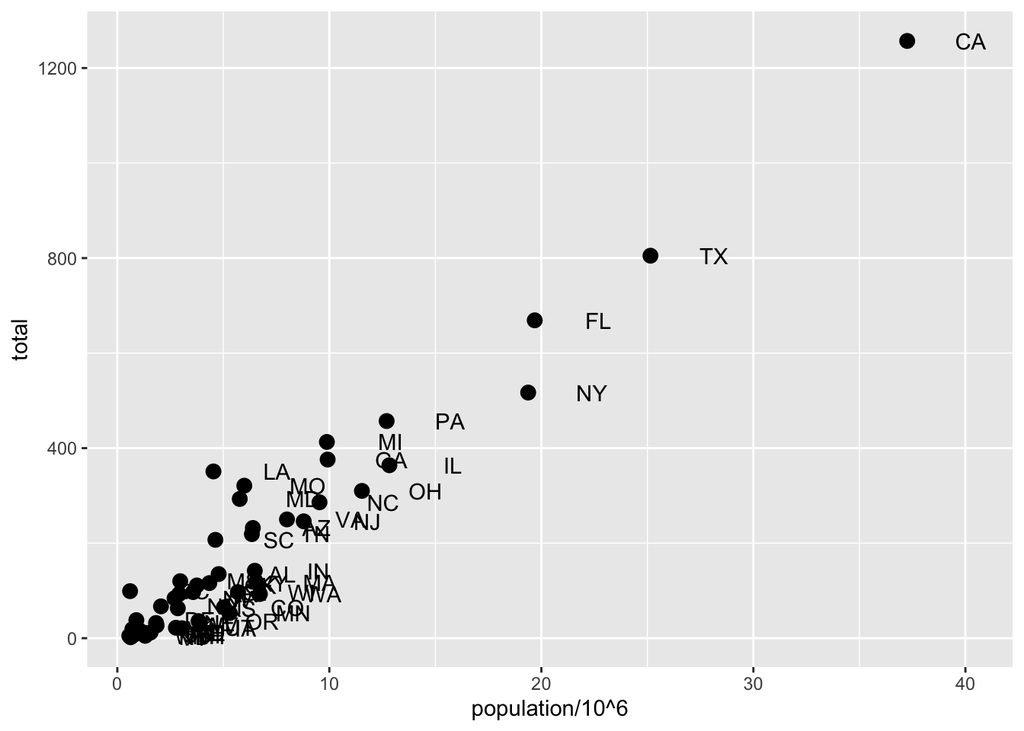

```r
p + geom_point(aes(population/10^6, total), size = 3) +
    geom_text(aes(population/10^6, total, label = abb), nudge_x = 3)
```

This is preferred as it makes it easier to read the text.

### Global aesthetic mappings

Note that in the previous line of code, we define the mapping `aes(population/10^6, total)` twice, once in each geometry. We can avoid this by using a *global* aesthetic mapping. We can do this when we define the blank slate `ggplot` object. Remember that the function `ggplot` contains an argument that permits us to define aesthetic mappings:

```r
args(ggplot)
```

```
## function (data = NULL, mapping = aes(), ..., environment = parent.frame())
## NULL
```

If we define a mapping in `ggplot`, then all the geometries that are added as layers will default to this mapping. We redefine `p`:

```r
p <- murders %>%
     ggplot(aes(x = population/10^6, y = total, label = abb))
```

and then we can simply use code like this:

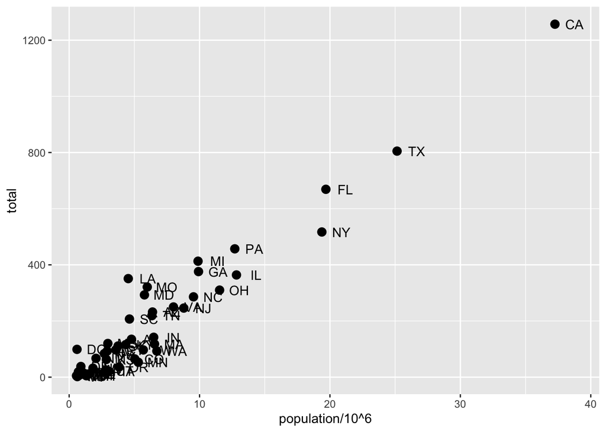

```r
p + geom_point(size = 3) +
    geom_text(nudge_x = 1.5)
```

We keep the `size` and `nudge_x` argument in `geom_point` and `geom_text` respectively because we only want to increase the size of points and nudge only the labels. Also note that the `geom_point` function does not need a `label` argument and therefore ignores it.

#### Local aesthetic mappings overide global ones

If we need to, we can override the global mapping by defining a new mapping within each layer. These *local* definitions override the *global*. Here is an example:

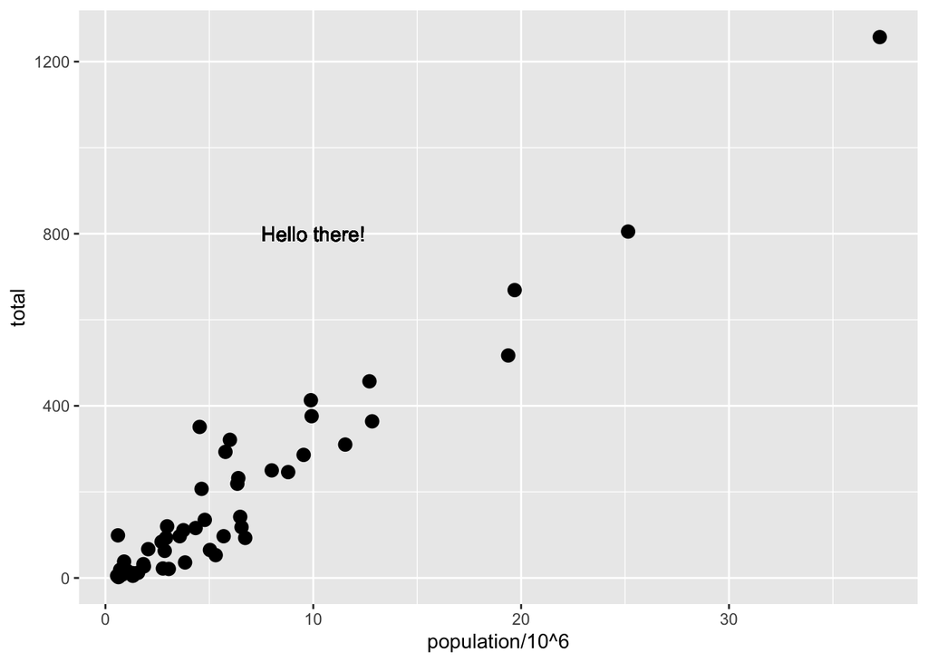

```r
p + geom_point(size = 3) +
    geom_text(aes(x = 10, y = 800, label = "Hello there!"))
```

Clearly, the second call to `geom_text` does not use `population` and `total` on the `x` and `y` axis.

### Scales

Recall that our desired scales are in log-scale. This is not the default so this change needs to be added through a *scales* layer. A quick look at the cheat sheet reveals `scale_x_continuous` is needed to edit the behavior of scales. We use it like this:

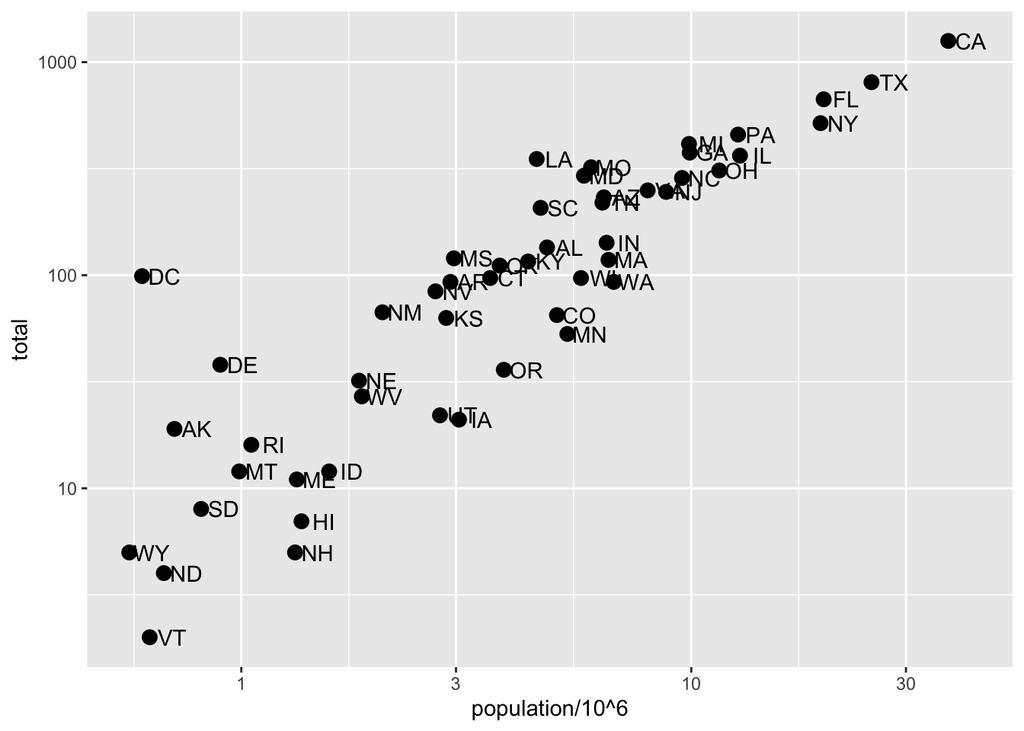

```r
p + geom_point(size = 3) +
    geom_text(nudge_x = 0.05) +
    scale_x_continuous(trans = "log10") +
    scale_y_continuous(trans = "log10")
```

Because we are in the log-scale now, the *nudge* must be made smaller.

This particular transformation is so common that `ggplot` provides specialized functions:

```r
p + geom_point(size = 3) +
    geom_text(nudge_x = 0.05) +
    scale_x_log10() +
    scale_y_log10()
```

### Labels and Titles

Similarly, the cheat sheet quickly reveals that to change labels and add a title we use the following functions: `xlab`, `ylab` and `ggtitle`.

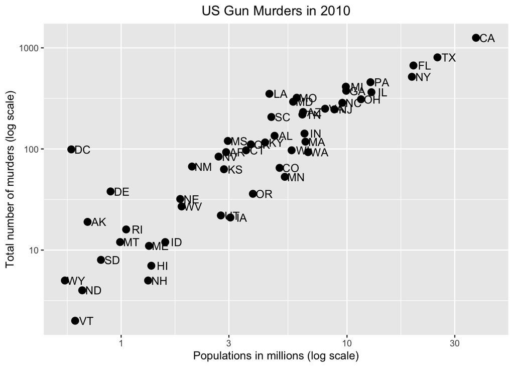

```r
p + geom_point(size = 3) +
    geom_text(nudge_x = 0.05) +
    scale_x_log10() +
    scale_y_log10() +
    xlab("Populations in millions (log scale)") +
    ylab("Total number of murders (log scale)") +
    ggtitle("US Gun Murders in 2010") +
    theme(plot.title = element_text(hjust = 0.5))
```

We are almost there! All we have to do is add color, a legend and optional changes to the style.

#### Categories as colors

Note that we can change the color of the points using the `color` argument in the `geom_point` function. To facilitate exposition we will redefine `p` to be everything except the points layer:

```r
p <-  murders %>%
      ggplot(aes(population/10^6, total, label = abb)) +
      geom_text(nudge_x = 0.05) +
      scale_x_log10() +
      scale_y_log10() +
      xlab("Populations in millions (log scale)") +
      ylab("Total number of murders (log scale)") +
      ggtitle("US Gun Murders in 2010")
```

and then test out what happens by adding different calls to `geom_point`. We can make all the points blue by adding the `color` argument:

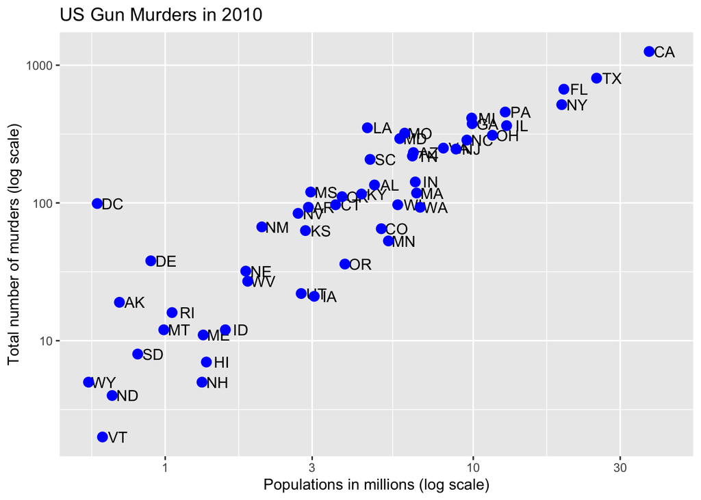

```r
p + geom_point(size = 3, color ="blue")
```

This, of course, is not what we want. We want to assign color depending on the geographical region. A nice default behavior of `ggplot2` is that if we assign a categorical variable to color, it automatically assigns a different color to each category. It also adds a legend!

To map each point to a color, we need to use `aes` since this is a mapping. So we use the following code:

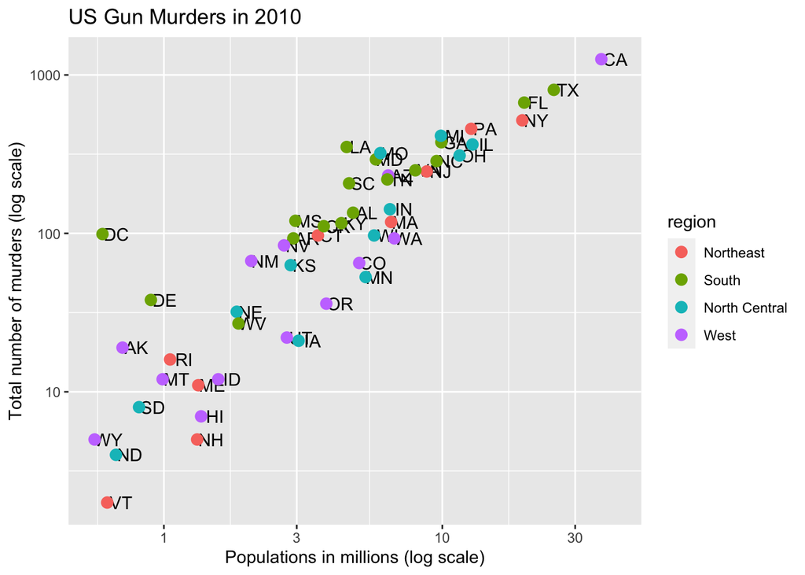

```r
p + geom_point(aes(color = region), size = 3)
```

The `x` and `y` mappings are inherited from those already defined in `p`. So we do not redefine them. We also move `aes` to the first argument since that is where the mappings are expected in this call.

Here we see yet another useful default behavior: `ggplot2` has automatically added a legend that maps color to region.

### Adding a line

We want to add a line that represents the average murder rate for the entire country. Note that once we determine the per million rate to be $r$, this line is defined by the formula: $y = r x$ with $y$ and $x$ our axes: total murders and population in millions respectively. In the log-scale this line turns into: $\log(y) = \log(r) + \log(x)$. So in our plot it’s a line with slope 1 and intercept $\log(r)$. To compute this value we use our `dplyr` skills:

```r
r <- murders %>%
     summarize(murder_rate = sum(total) /  sum(population) * 10^6) %>% .$murder_rate
r
```

```
## [1] 30.34555
```

To add a line we use the `geom_abline` function. `ggplot` uses `ab` in the name to remind us we are supplying the intercept (`a`) and slope (`b`). The default line has slope 1 and intercept 0 so we only have to define the intercept:

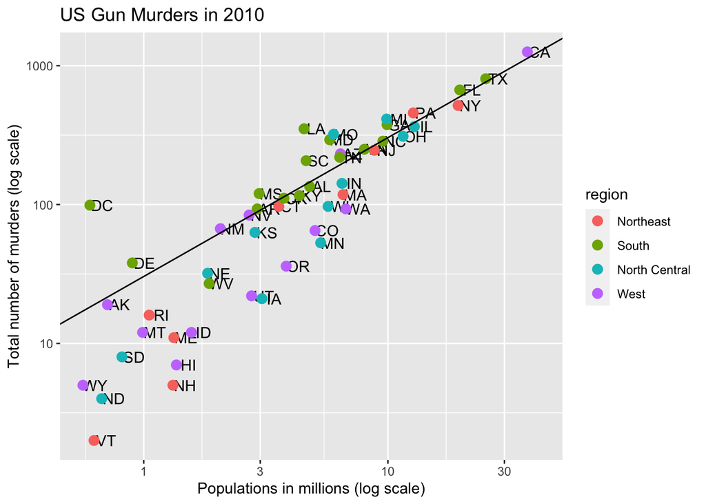

```r
p + geom_point(aes(col=region), size = 3) +
    geom_abline(intercept = log10(r))
```

We can change the line type and color of the lines using arguments. We also draw it first so it doesn’t go over our points.

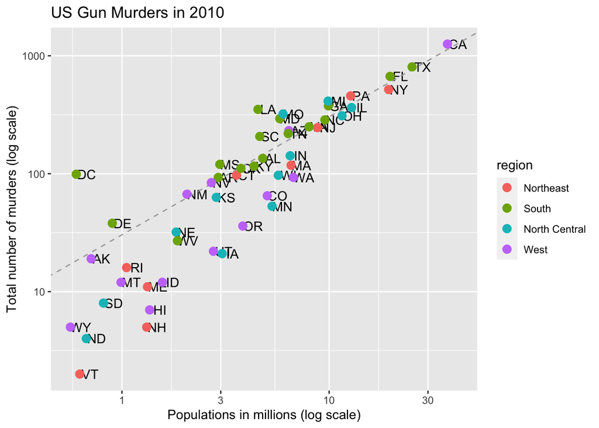

```r
p <- p + geom_abline(intercept = log10(r), lty = 2, color = "darkgrey") +
         geom_point(aes(color = region), size = 3)
p
```

Note that we redefined `p`.

### Other adjustments

The default plots created by `ggplot` are already very useful. But often, we need to make minor tweaks to the default behavior. Although it is not always obvious how to make these even with the cheat sheet, `ggplot2` is very flexible.

For example, note that we can make changes to the legend via the `scale_color_discrete` function. For example, in our plot the word *region* is not capitalized. We can change that like this:

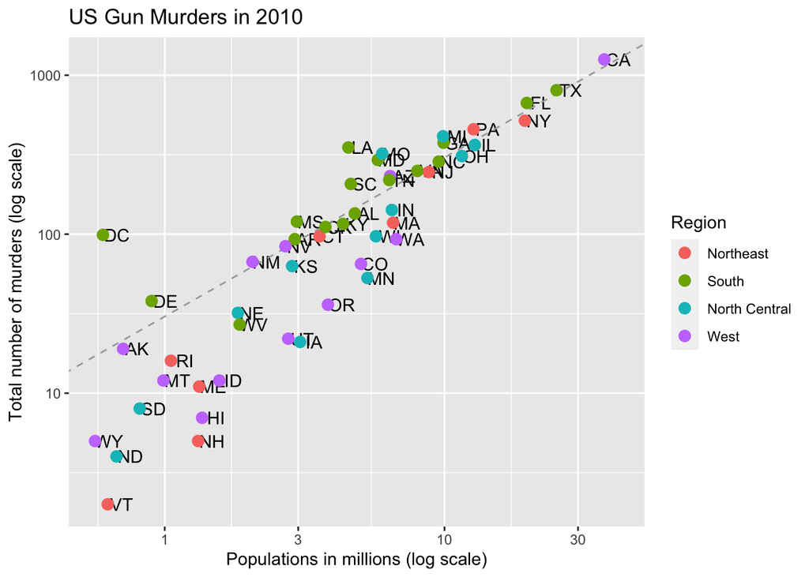

```r
p <- p + scale_color_discrete(name = "Region")
p
```

### Add-on packages

The power of `ggplot2` is augmented further due to the availability of add-on packages. The remaining changes required to put the finishing touches on our plot require the `ggthemes` and `ggrepel` packages.

The style of a `ggplot` graph can be changed using the `theme` functions. Several themes are included as part of the `ggplot2` package. In fact, for most of the plots in this course we use a function in the `dslabs` package that automatically sets a default theme:

```r
ds_theme_set()
```

Many other themes are added by the package `ggthemes`. Among those are the `theme_economist` theme that we used. After installing the package, you can change the style of the plot by adding a layer:

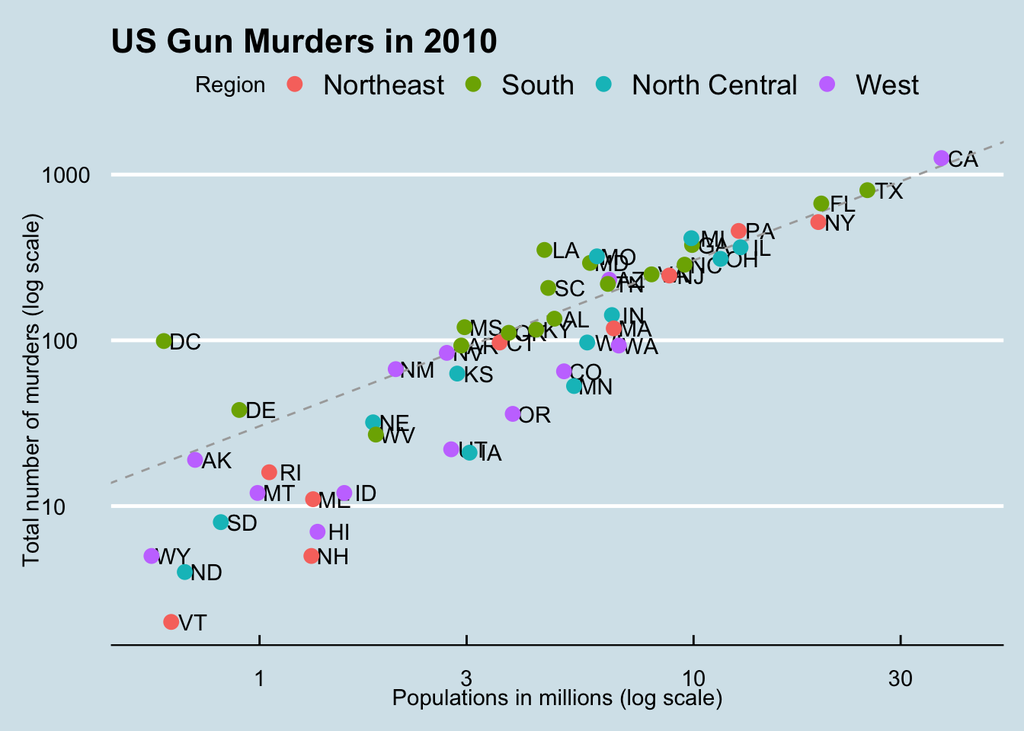

```r
library(ggthemes)
p + theme_economist()
```

You can see how some of the other themes look like by simply changing the function. For example you might try the `theme_fivethirtyeight()` theme instead.

The final difference has to do with the position of the labels. Note that in our plot, some of the labels fall on top of each other. The add-on package `ggrepel` includes a geometry that adds labels ensuring that they don’t fall on top of each other. We simply change `geom_text` with `geom_text_repel`.

### Putting it all together

So now that we are done testing we can write one piece of code that produces our desired plot from scratch.

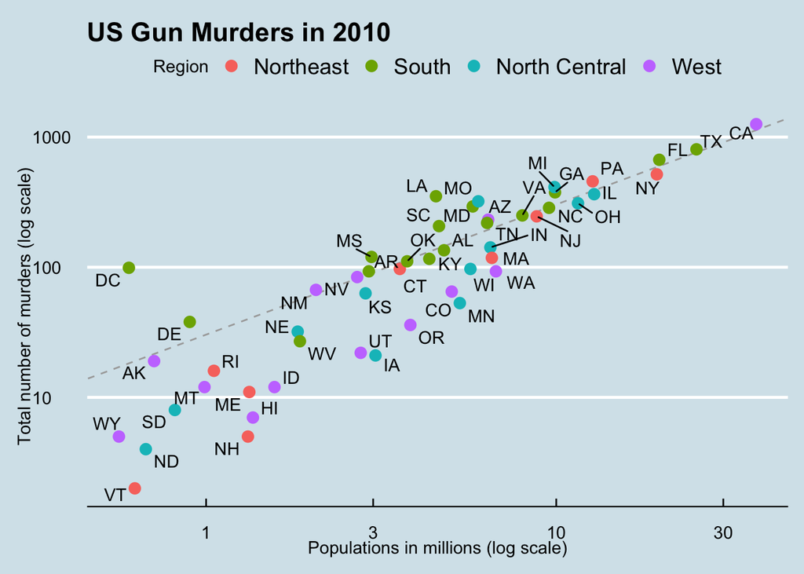

```r
library(ggthemes)
library(ggrepel)

### First define the slope of the line
r <- murders %>%
     summarize(murder_rate= sum(total) /  sum(population) * 10^6) %>% .$murder_rate

## Now make the plot
murders %>% ggplot(aes(population/10^6, total, label = abb)) +
  geom_abline(intercept = log10(r), lty = 2, color = "darkgrey") +
  geom_point(aes(col=region), size = 3) +
  geom_text_repel() +
  scale_x_log10() +
  scale_y_log10() +
  xlab("Populations in millions (log scale)") +
  ylab("Total number of murders (log scale)") +
  ggtitle("US Gun Murders in 2010") +
  scale_color_discrete(name = "Region") +
  theme_economist()
```